# kaalavarsham

```python
from monsoon_functions import *
import numpy as np
import pandas as pd
import matplotlib.pyplot as plt
```

```python
from IPython.display import HTML

HTML('''<script>
code_show=true;
function code_toggle() {
 if (code_show){
 $('div.input').hide();
 } else {
 $('div.input').show();
 }
 code_show = !code_show
}
$( document ).ready(code_toggle);
</script>
The raw code for this project is by default hidden for easier reading.
To toggle on/off the raw code, click <a href="javascript:code_toggle()">here</a>.''')
```

The raw code for this project is by default hidden for easier reading. To toggle on/off the raw code, click here.

```python
HTML('''<img src="kalavarsham.png">''')
```

[figure not shown]

Welcome to Kaalavarsham: an exploration of the past, present, and future of monsoons in my family's home state of Kerala, India. Note that all centered text in quotations are the words of my Ammoomma (grandmother), which have been edited with some connecting words and punctuation to make clearer to an American audience.  
Click any images not created by me to go to the site they originate from. Graphs that I made have links to their datasets below them. Finally, there are footnote-esque citations for information that I didn't know off the top of my head.

# Pre-humans

### "The monsoon's Malayalam name is കാലവർഷം [kaalavarsham]... For me, it is nature's play with the land to help agriculture, land, plants, animals, etc. at the correct time twice in a year."

```python
HTML('''
<center><video width="480" height="270" controls>
    <source src="monsoon_intro.mp4" type="video/mp4">
Your browser does not support the video tag.
</video>
''')
```

[video not shown]

```python
HTML('''
<center>full video: <a href="https://www.youtube.com/watch?v=XqssftOuQXI" target="_blank">
https://www.youtube.com/watch?v=XqssftOuQXI</a>
''')
```

full video: https://www.youtube.com/watch?v=XqssftOuQXI

```python
HTML('''<center><a href="https://timesofindia.indiatimes.com/india/the-monsoons-date-with-india/articleshow/64368228.cms"
    target="_blank">
    <img src="monsoon_path.gif", width="423", height="552"></a>''')
```

[figure not shown]

# 800s

Onam is the biggest holiday of the year in Kerala. I've completely internalized its origin story, having heard it dozens of times since I was a kid...

Long ago, a king named Mahabali ruled Kerala. He was a just and kind king. In his kingdom, everyone was treated fairly, and there was little sickness or crime. However, Mahabali also happened to be an Asura (a type of demon), and the gods began to fear his power. They decided it was the right time to overthrow him. All the gods got together to ask Vishnu (one of the major Hindu gods) if he would go to earth in human form and defeat Mahabali. Vishnu agreed.

During his reign, Mahabali held an enormous event each year where his subjects would come to the palace courtyard and ask for whatever they desired, and he would try his best to fulfill their wishes. This incredible generosity was one of the reasons that the people of Kerala loved and respected him so much. Vishnu chose a form to incarnate into; a short mendicant named Vamana, and slipped unnoticed into the long line of fortune-seekers waiting for their audience with Mahabali.

He waited for hours and hours, but finally he reached the throne room, and was informed that he would be the last one who would meet the king that day. Mahabali authoritatively asked what this poor man wanted, and Vamana smiled innocently up at him.

"Sir, all I want is three feet's worth of land," he said.

"Surely there is something more I can give you?" replied Mahabali, puzzled. This man clearly had no possessions to his name, and was dressed in beggars' rags, and the king was sure there was something more he could give away. "I have gold, jewelry, houses... you name it and it's yours."

"No sir," Vamana said, bowing his head. "Just as much land as I can cover with my feet thrice over."

Mahabali was confused, but he was agreed. "Alright then, my modest friend. Pick anywhere in the kingdom you wish, measure out your three feet, and it shall be yours."

Vamana smiled again. Then he began to grow, and grow, and grow. Mahabali was astonished. Vamana continued to grow, and grow, until he reached his full height, towering so far above the king that his head couldn't be seen. Mahabali knew immediately that this was the work of the gods, and, being a devout man, he scrambled to kneel before Vamana and bow his head. From above, Vamana's voice boomed: "With my first foot, I shall cover all the land of the earth." And he did.

He continued: "With my second foot, I shall cover all of the heavens." And he did. Mahabali trembled now, in awe of the god's power.

Vamana looked down at the very small king. "I have claimed the earth and the heavens for the gods," he said, "but tell me, where can I place my final footstep?"

Mahabali knew know why Vamana had come to him, and said reverently, "please Lord, place it here on my head." He prostrated himself before the god, and readied himself. "But before you do, I have one request. I have been a devout follower of God my entire life. I love the people in this kingdom, and I know they will miss me. So, please, may I come back here to see them every so often?"

Vamana considered for a minute. "Yes, you have been a good man. You have created this beautiful and kind kingdom, and done so in service to Me. So, every year, I will allow you to come back and wander the kingdom, and your subjects will greet you and honor you." And with that, Vamana placed his foot on Mahabali's head, and pushed him down into the Underworld.

The people of Kerala grieved, but they knew their king would return. Every year now, they eat feasts together, and create mandalas with flower petals outside their homes, to welcome Mahabali as he visits. If you keep an eye out, you may just see him.

So that's the story of Onam. In historical reality, Onam first appeared in the 800s. It was most likely started to mark the end of the monsoon, prepare for the harvest, and celebrate a successful year of crops[1]. Families and communities were grateful for the turn of weather and their good fortune as beneficiaries of Kerala's rich natural world. The monsoon's cycles had and have an enormous impact on people's lives, so it's natural that their biggest, most extravagant celebration is most likely based around it. I share the mythology, though, to give you a glimpse of the epic tales and moral lessons that are spun out around the monsoon and its legacies — Onam is just one of those.

1. https://www.theholidayspot.com/onam/onam_history.htm

# 1600s

### "Monsoon comes after the summer hot season. So, all welcome the monsoon. Festivals of harvest in Kuttanadu, Palaghat, etc. are done in the monsoon. Boat races are done in the monsoon."

```python
HTML('''<audio controls>
            <source src="kuttanadan_punchayile.mp3" type="audio/mpeg">
            Your browser does not support the audio element.
    </audio>
    <a href="https://www.sciencedirect.com/science/article/pii/S2214241X15000644"
    target="_blank">
    <img src="snakeboat_pressure.png"></a>''')
```

[interactive chart not shown]

[figure not shown]

Snakeboats are an iconic Kerala sight. They are essentially very long canoes, sometimes paddled by over 100 people at once. They slice through the water incredibly fast, racing each other in boat races called Vallam Kali (literally, "water play"). The song above is one that would be used to keep time so that the rowers are perfectly synchronized.

The canoes were created in the 1600s, as a war tool for navies to get the upper hand in the state's intricate backwaters[1]. Now, of course, they are just used for the glory of winning a boat race. The backwaters have always been vital for society in Kerala. Rice paddies and other heavily water-dependent agriculture thrive, and goods and people travel over the water between towns and cities[2].

Most of the time I spend in Kerala is during the rainy season. The backwaters and their surrounding ecosystems become lush and very, very green. The boat races happen at the end of the monsoon, around the time of Onam, while all this natural beauty is on full display. It's a celebratory time of year, and feels even more so because of the freshness brought by the monsoon.

1. https://theculturetrip.com/asia/india/articles/this-400-year-old-tradition-of-snake-boat-racing-in-india-is-truly-unique/
2. https://www.savingwetlands.com/wetlands-around-the-world/the-kerala-backwaters/

# Post-independence

### "I remember my school days. Every year, the reopening day after 2 months vacation was on June Ist. That morning, monsoon rain would start. We had no vehicles to travel. We'd go by walking. I remember how carefully we kept our new books with us. Our uniform would become wet when we walked to school. We took umbrellas. "Even if a little difficult, we walked to school with friends enjoying the rain. We walked without chappals [sandals]. The monsoon rain never disturbed us on those days. Time has changed, and now all roads are filled with vehicles."

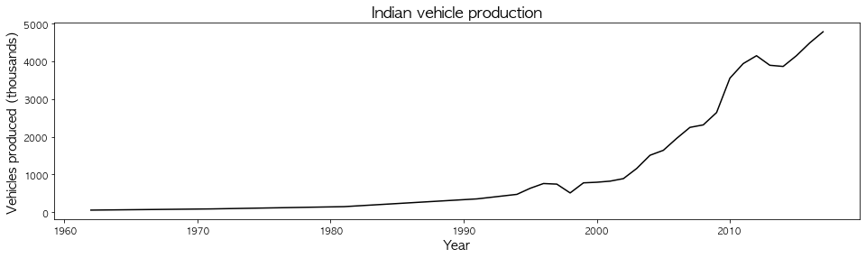

```python
cars_raw = pd.read_csv("india_car_manufacturing.csv")
plt.figure(figsize=(16,4))
plt.plot(cars_raw.iloc[:,0], cars_raw.iloc[:,1], 'k')
plt.title("Indian vehicle production", fontname="AppleGothic", fontsize="xx-large")
plt.xlabel("Year", fontname="AppleGothic", fontsize="x-large")
plt.ylabel("Vehicles produced (thousands)", fontname="AppleGothic", fontsize="x-large")
plt.xticks(fontname="AppleGothic", fontsize="medium")
plt.yticks(fontname="AppleGothic", fontsize="medium")
plt.show()
```

data: https://www.bts.gov/content/world-motor-vehicle-production-selected-countries

# 2018

### "The state of Kerala saw the worst flood of the century in 2018. So many houses fell down. The flood in Kerala damaged many places. So many people died because pralayam [flood; deluge] came unexpectedly. Animals like cows and many other animals lost their life. Because of the strong flood nobody could travel. Many vehicles also got damaged. Our house was at a higher level, and I could help some people to come and stay here."

```python
HTML('''<a href="https://graphoverflow.com/graphs/kerala-flood-2018.html"
    target="_blank">
    <img src="2018.png"></a>''')
```

[figure not shown]

In 2018, Kerala faced a devastating monsoon season. Dams were opened, landslides and floods destroyed entire towns, and hundreds of people lost their lives.

My sister and I had been in Kerala to visit right at the beginning of the season, but we left before the most intense weather started. My grandfather had passed away that year, and we visited a temple to pay respects and go to the river where his ashes were scattered. It dumped rain while we were there, the kind of dense driving rain that I've only seen in Kerala. Later that summer, my grandmother told us that the entire temple was now flooded.

This summer, just a year after the chaos of the 2018 monsoon, I drove with my family through the mountains in Kerala. At one point, we were passing a village in a deep valley off the side of the road. My uncle told me that the entire place had been completely covered in water a year ago. I was shocked not just because of the severity of the monsoon (I only heard what made the international news and what was relayed to me over FaceTime), but because the entire community seemed to be intact and rebuilt. I never would have guessed that it went through a devastating natural disaster less than 12 months earlier.

## Looking forward

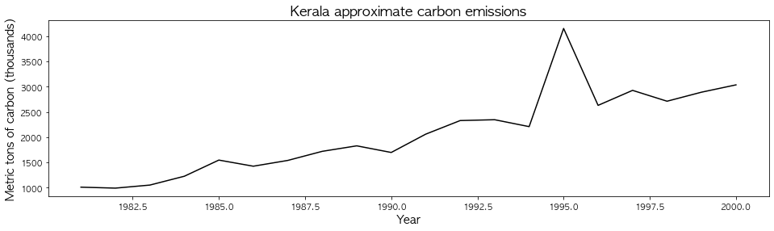

```python
carbon_raw = pd.read_csv("carbon.csv")
plt.figure(figsize=(16,4))
plt.plot(carbon_raw.iloc[:,0], carbon_raw.iloc[:,1], 'k')
plt.title("Kerala approximate carbon emissions", fontname="AppleGothic", fontsize="xx-large")
plt.xlabel("Year", fontname="AppleGothic", fontsize="x-large")
plt.ylabel("Metric tons of carbon (thousands)", fontname="AppleGothic", fontsize="x-large")
plt.xticks(fontname="AppleGothic", fontsize="medium")
plt.yticks(fontname="AppleGothic", fontsize="medium")
plt.show()
```

data: http://citeseerx.ist.psu.edu/viewdoc/download?doi=10.1.1.683.5331&rep=rep1&type=pdf

There is a huge potential in India to reach the carbon neutrality goal of the Paris Accords. It's still a "developing" country, which reminds me of the Hans Rosling video. In Kerala's case (and India as a whole), a focus on sustainability would actually be a huge source of technological development; environmental issues are a means and not just a goal.

Since 2015, our first sight when we touch down at the airport and drive into Kochi, where my grandmother lives, is miles of solar panels dedicated to powering the airport. It's the first airport in the world to be completely solar powered. The parking facilities of the international and domestic terminal also comprise the world's largest solar carport. Thanks to these advancements, I can't help but have pride as my first emotion when we arrive.

My grandfather, too, upgraded his house to solar power before he passed away. So, in the middle of Changampuzha Nagar, one little whitewashed house with a sign that says "le Nid" (he studied French during college) generates power from the sun to put back into the grid.

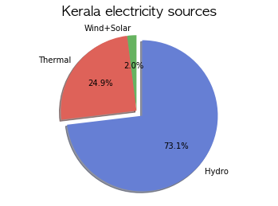

```python
labels = 'Wind+Solar', 'Thermal', 'Hydro'
sizes = [2.0, 24.9, 73.1]
explode = (0, 0, 0.1)  # only "explode" the 2nd slice (i.e. 'Hogs')

fig1, ax1 = plt.subplots()
ax1.pie(sizes, explode=explode, labels=labels, autopct='%1.1f%%',
        shadow=True, startangle=90, colors=['#66b360','#de6259','#667fd4'])
ax1.axis('equal')
plt.title("Kerala electricity sources", fontname="AppleGothic", fontsize="xx-large", pad=15)
plt.show()
```

data: http://spb.kerala.gov.in/EconomicReview2016/web/chapter05_09.php

And, of course, the ultimate solution may lie in the monsoon. In between landslides and boat races, festivals and floods, the monsoon drives the vibrant water system that supplies almost 3/4 of Kerala's energy.

Hydroelectric power creates no carbon emissions. It isn't possible everywhere in the world, but Kerala's environment is perfectly suited to it. The government is making an active effort to make the most of this resource—between 2013 and 2018, thermal power capacity state-wide was decreased from 434 MW to 317 MW, while hydroelectric was raised from 2064 MW to 2122 MW[1].

As Kerala moves into a future where extreme monsoons and droughts may become more frequent, and a booming population drives up power use, hydrolectric power should become a point of pride. If the government can continue to push it to the forefront, the mythos and cultural legacy around monsoons may just develop a new facet: their use as the power source for an entire state and the lives of everyone in it.

1. http://www.kerenvis.nic.in/Database/Energy_831.aspx

# Sources & Further Reading

```python
HTML('''
<a href="https://www.theatlantic.com/photo/2018/08/devastating-monsoon-floods-in-kerala-india/568171/"
target="_blank">Photographs from the 2018 monsoon</a><br>

<a href="https://aeon.co/essays/the-life-and-possible-death-of-the-great-asian-monsoon"
target="_blank">"When the Monsoon Goes Away"</a><br>

<a href="https://timesofindia.indiatimes.com/city/kochi/why-keralas-monsoon-is-no-longer-the-same/articleshow/70614363.cms"
target="_blank">"Why Kerala's Monsoon is No Longer the Same"</a><br>

<a href="https://www.nature.com/articles/nclimate2208.epdf?referrer_access_token=55gNMSenKZx1jC5TykeWQ9RgN0jAjWel9jnR3ZoTv0OhxlH9PJLxefPCshfldCDsawQvfY_qe7somGU_1Ox5VREd-pxSdYQ28R3HZFUAW0hWOmBGMfpud5odL5N83jLkbzTeU-PQaepFtaM-TdHREMoMjYZcdWVZ-P_eECTaiEt6m3hOo-aeq5V1zfzJnKPrdXEsLzr7U9bbqqMc26o2DToxOkC0xe1sKDma9nH8kSLE1ZPI0r0WFCPf-bsYqUm-LTmzfuaHPaJyJrFK8KXTeA%3D%3D&tracking_referrer=www.scientificamerican.com"
target="_blank">"Observed changes in extreme wet and dry spells during the South Asian summer monsoon season"</a><br>

<a href="https://www.indiatoday.in/india-today-insight/story/why-global-warming-has-left-kerala-vulnerable-1612792-2019-10-25"
target="_blank">"Why global warming has left Kerala vulnerable"</a>
''')
```

[Photographs from the 2018 monsoon](https://www.theatlantic.com/photo/2018/08/devastating-monsoon-floods-in-kerala-india/568171/)  
["When the Monsoon Goes Away"](https://aeon.co/essays/the-life-and-possible-death-of-the-great-asian-monsoon)  
["Why Kerala's Monsoon is No Longer the Same"](https://timesofindia.indiatimes.com/city/kochi/why-keralas-monsoon-is-no-longer-the-same/articleshow/70614363.cms)  
"Observed changes in extreme wet and dry spells during the South Asian summer monsoon season"  
["Why global warming has left Kerala vulnerable"](https://www.indiatoday.in/india-today-insight/story/why-global-warming-has-left-kerala-vulnerable-1612792-2019-10-25)

```python
from monsoon_functions import *
import numpy as np
import pandas as pd
import matplotlib.pyplot as plt
```

```python
area_raw = pd.read_csv("area_rainfall.csv")
area_raw = area_raw.set_index("SD_Name")
kerala_data = area_raw.loc["KERALA"]
```

```python
def graph_yearly(col1,col2):
    plt.figure(figsize=(16,4))
    plt.plot(np.linspace(1951,2015,64*(col2-col1)), kerala_data.iloc[:,col1:col2].to_numpy().flatten(), color='k')
    plt.xlabel("Year", fontname="AppleGothic", fontsize="x-large")
    plt.ylabel("Amount of rain (mm)", fontname="AppleGothic", fontsize="x-large")
    plt.xticks(fontname="AppleGothic", fontsize="medium")
    plt.yticks(fontname="AppleGothic", fontsize="medium")
    plt.show()
```

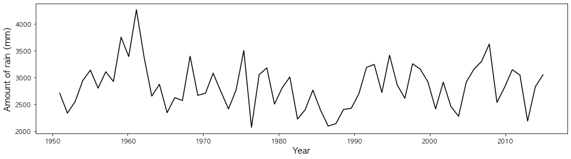

```python
graph_yearly(14,15)
```

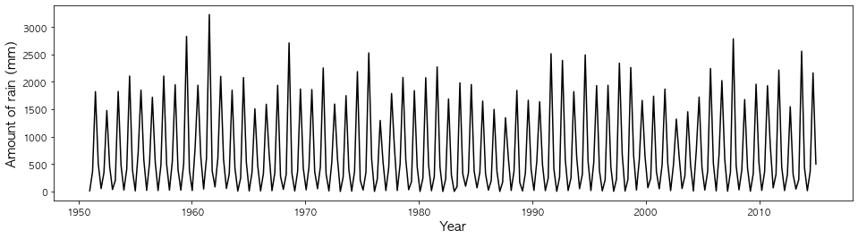

```python
graph_yearly(15,19)
```

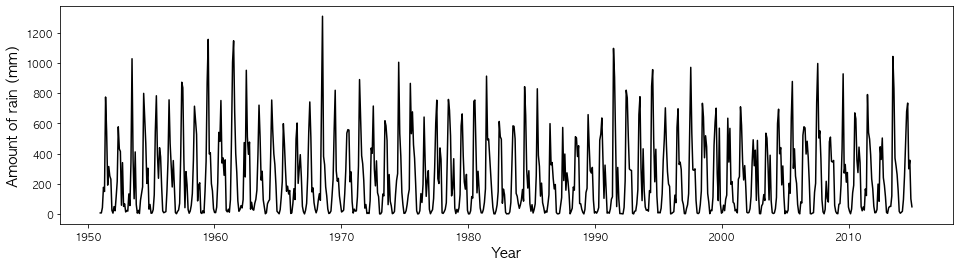

```python
graph_yearly(2,14)
```